# Attrition Analyis

Connor Dobbs

11/14/2021

# Introduction:

#### The CEO AND CFO have tasked outside consultant Connor Dobbs to investigate Employee Attrition and Income trends.

#### With the rising importance of employee rentention in the current labor market, there have been a few specific goals outlined for this research to help minimize attrition and maintain Frito-Lay’s strong talent pool.

1. Identify the three most important factors associated with attrition
2. Identify the most important factors associated with employee income
3. Identify any other potentially useful trends or patterns within the data
4. Develop a model to predict employee attrition
5. Develop a model to predict Monthly Income

#### This investigation finds strong trends with age, job role, and overtime status leading to attrition that can be focused on moving forward to improve rention. A full conclusion summary with recommendations is at the end of the document and can be skipped to via the table of contents to the left.

## Tools used

#### Human Resources has kindly provided the dataset to be used for this analysis. Data visulizations were used to explore the data and relationships within it.

#### Statistical methods used include: KNN classification, linear regression, and Naive-Bayes classification

#### Additional questions about the results can be directed towards Connor Dobbs via e-mail: dobbs@smu.edu

##### *Note, all code chunks are hidden by default. There is an option to the right of each chunk to expand/collapse. You can also expand/collapse all with the Code button on the top right of this document.

# Initial Steps:

Begin by loading the data and initial cleaning. There is no missing values which is good, however there are some variables that appear to be of no use to be removed.

```r
#load in hr data
hrdf <- read.csv('Data/CaseStudy2-data.csv')

#check for NA, get familiar with distributions
skim(hrdf)
```

Data summary

| Name | hrdf |
| --- | --- |
| Number of rows | 870 |
| Number of columns | 36 |
| _______________________ |  |
| Column type frequency: |  |
| character | 9 |
| numeric | 27 |
| ________________________ |  |
| Group variables | None |

**Variable type: character**

| skim_variable | n_missing | complete_rate | min | max | empty | n_unique | whitespace |
| --- | --- | --- | --- | --- | --- | --- | --- |
| Attrition | 0 | 1 | 2 | 3 | 0 | 2 | 0 |
| BusinessTravel | 0 | 1 | 10 | 17 | 0 | 3 | 0 |
| Department | 0 | 1 | 5 | 22 | 0 | 3 | 0 |
| EducationField | 0 | 1 | 5 | 16 | 0 | 6 | 0 |
| Gender | 0 | 1 | 4 | 6 | 0 | 2 | 0 |
| JobRole | 0 | 1 | 7 | 25 | 0 | 9 | 0 |
| MaritalStatus | 0 | 1 | 6 | 8 | 0 | 3 | 0 |
| Over18 | 0 | 1 | 1 | 1 | 0 | 1 | 0 |
| OverTime | 0 | 1 | 2 | 3 | 0 | 2 | 0 |

**Variable type: numeric**

| skim_variable | n_missing | complete_rate | mean | sd | p0 | p25 | p50 | p75 | p100 | hist |
| --- | --- | --- | --- | --- | --- | --- | --- | --- | --- | --- |
| ID | 0 | 1 | 435.50 | 251.29 | 1 | 218.25 | 435.5 | 652.75 | 870 | ▇▇▇▇▇ |
| Age | 0 | 1 | 36.83 | 8.93 | 18 | 30.00 | 35.0 | 43.00 | 60 | ▂▇▇▃▂ |
| DailyRate | 0 | 1 | 815.23 | 401.12 | 103 | 472.50 | 817.5 | 1165.75 | 1499 | ▇▇▇▇▇ |
| DistanceFromHome | 0 | 1 | 9.34 | 8.14 | 1 | 2.00 | 7.0 | 14.00 | 29 | ▇▅▂▂▂ |
| Education | 0 | 1 | 2.90 | 1.02 | 1 | 2.00 | 3.0 | 4.00 | 5 | ▂▅▇▆▁ |
| EmployeeCount | 0 | 1 | 1.00 | 0.00 | 1 | 1.00 | 1.0 | 1.00 | 1 | ▁▁▇▁▁ |
| EmployeeNumber | 0 | 1 | 1029.83 | 604.79 | 1 | 477.25 | 1039.0 | 1561.50 | 2064 | ▇▇▇▇▇ |
| EnvironmentSatisfaction | 0 | 1 | 2.70 | 1.10 | 1 | 2.00 | 3.0 | 4.00 | 4 | ▅▆▁▇▇ |
| HourlyRate | 0 | 1 | 65.61 | 20.13 | 30 | 48.00 | 66.0 | 83.00 | 100 | ▇▇▆▇▇ |
| JobInvolvement | 0 | 1 | 2.72 | 0.70 | 1 | 2.00 | 3.0 | 3.00 | 4 | ▁▃▁▇▁ |
| JobLevel | 0 | 1 | 2.04 | 1.09 | 1 | 1.00 | 2.0 | 3.00 | 5 | ▇▇▃▂▁ |
| JobSatisfaction | 0 | 1 | 2.71 | 1.11 | 1 | 2.00 | 3.0 | 4.00 | 4 | ▅▅▁▇▇ |
| MonthlyIncome | 0 | 1 | 6390.26 | 4597.70 | 1081 | 2839.50 | 4945.5 | 8182.00 | 19999 | ▇▅▂▁▁ |
| MonthlyRate | 0 | 1 | 14325.62 | 7108.38 | 2094 | 8092.00 | 14074.5 | 20456.25 | 26997 | ▇▇▇▇▇ |
| NumCompaniesWorked | 0 | 1 | 2.73 | 2.52 | 0 | 1.00 | 2.0 | 4.00 | 9 | ▇▃▂▂▁ |
| PercentSalaryHike | 0 | 1 | 15.20 | 3.68 | 11 | 12.00 | 14.0 | 18.00 | 25 | ▇▅▃▂▁ |
| PerformanceRating | 0 | 1 | 3.15 | 0.36 | 3 | 3.00 | 3.0 | 3.00 | 4 | ▇▁▁▁▂ |
| RelationshipSatisfaction | 0 | 1 | 2.71 | 1.10 | 1 | 2.00 | 3.0 | 4.00 | 4 | ▅▅▁▇▇ |
| StandardHours | 0 | 1 | 80.00 | 0.00 | 80 | 80.00 | 80.0 | 80.00 | 80 | ▁▁▇▁▁ |
| StockOptionLevel | 0 | 1 | 0.78 | 0.86 | 0 | 0.00 | 1.0 | 1.00 | 3 | ▇▇▁▂▁ |
| TotalWorkingYears | 0 | 1 | 11.05 | 7.51 | 0 | 6.00 | 10.0 | 15.00 | 40 | ▇▇▂▁▁ |
| TrainingTimesLastYear | 0 | 1 | 2.83 | 1.27 | 0 | 2.00 | 3.0 | 3.00 | 6 | ▂▇▇▂▃ |
| WorkLifeBalance | 0 | 1 | 2.78 | 0.71 | 1 | 2.00 | 3.0 | 3.00 | 4 | ▁▃▁▇▂ |
| YearsAtCompany | 0 | 1 | 6.96 | 6.02 | 0 | 3.00 | 5.0 | 10.00 | 40 | ▇▃▁▁▁ |
| YearsInCurrentRole | 0 | 1 | 4.20 | 3.64 | 0 | 2.00 | 3.0 | 7.00 | 18 | ▇▃▂▁▁ |
| YearsSinceLastPromotion | 0 | 1 | 2.17 | 3.19 | 0 | 0.00 | 1.0 | 3.00 | 15 | ▇▁▁▁▁ |
| YearsWithCurrManager | 0 | 1 | 4.14 | 3.57 | 0 | 2.00 | 3.0 | 7.00 | 17 | ▇▂▅▁▁ |

```r
# Changing the datatype to factors for relevant variables
cols <- c("Education", "EnvironmentSatisfaction", "JobInvolvement", "JobLevel",
         "JobSatisfaction", "PerformanceRating", "RelationshipSatisfaction",
         "StockOptionLevel", "TrainingTimesLastYear", "WorkLifeBalance",
         "Attrition", "BusinessTravel", "Department", "EducationField",
         "Gender", "JobRole", "MaritalStatus", "Over18", "OverTime")

hrdf[cols] <- lapply(hrdf[cols], factor)

#remove variables that add should add no info unless leakage (employee count, etc.)
hrdf <- subset(hrdf, select = -c(EmployeeCount, EmployeeNumber, Over18, StandardHours))
```

#### Quick overview of attrition distribution - It appears to be fairly unbalanced, with only 16% of the data a “yes”.

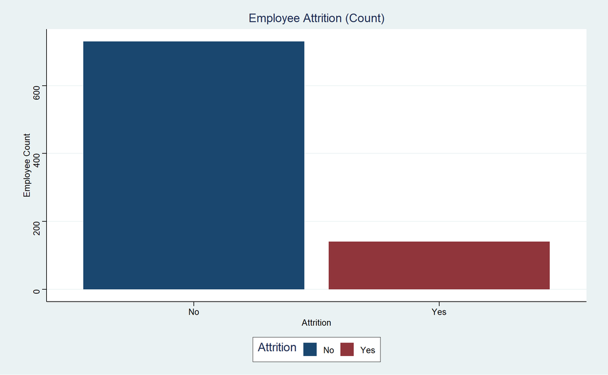

```r
#plot attrition - unbalanced data with only 16% yes
hrdf %>% ggplot(aes(x = Attrition, fill = Attrition)) + geom_bar() +
  theme_stata() + ggtitle("Employee Attrition (Count)") + ylab("Employee Count") +
    scale_fill_stata()
```

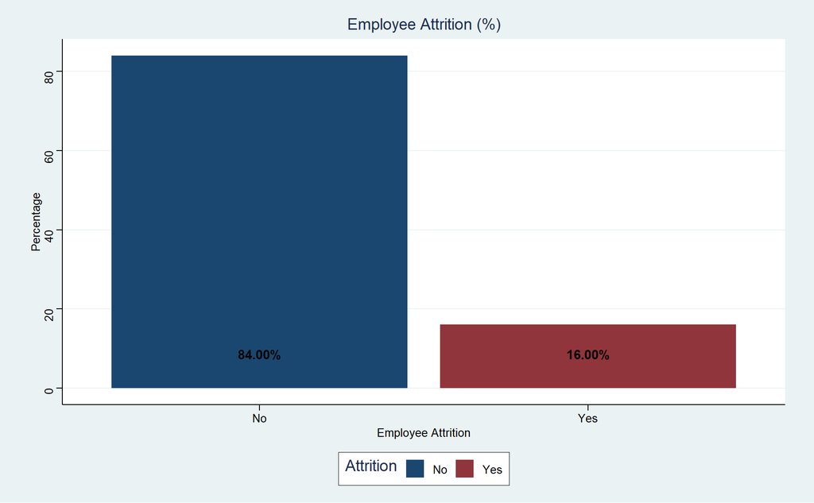

```r
hrdf %>% group_by(Attrition) %>% summarize(count = n()) %>% mutate(pct=round(prop.table(count),2) * 100) %>%
  ggplot(aes(x = Attrition, y = pct, fill = Attrition)) + geom_bar(stat = 'identity') +
  theme_stata() + ggtitle("Employee Attrition (%)") + ylab("Attrition %") +
  geom_text(aes(x=Attrition, y=0.01, label= sprintf("%.2f%%", pct)),
            hjust=0.5, vjust=-3, size=4,
            colour="black", fontface="bold") + labs(x="Employee Attrition", y="Percentage") +
    scale_fill_stata()
```

### Create Functions for EDA

```r
bar_plot_check <- function(x, y){

  x <- enquo(x)
  y <- enquo(y)
  varName <- as_label(enquo(x))
  varName <- str_to_title(str_replace(varName, "Group", ""))

  plot1 <- hrdf %>% group_by(!!x) %>% summarize(count = n()) %>% mutate(pct=round(prop.table(count),2) * 100) %>%
    ggplot(aes(x = !!x, y = count, fill = !!x)) + geom_bar(stat = 'identity', position = 'dodge', alpha = .7) +
    theme_stata() + ggtitle(glue("{varName} Distribution")) + ylab("Count") +
    geom_text(aes(x = !!x, y=0.01, label= sprintf("%.2f%%", pct)),
              hjust=0.5, vjust=-3, size=4, position = position_dodge(0.9),
              colour="black", fontface="bold") + labs(x =glue("{varName}"), y="Count") +
      scale_fill_stata()

  plot2 <-
    hrdf %>% group_by(!!x, !!y) %>% summarize(count = n()) %>% mutate(pct=round(prop.table(count),2) * 100) %>%
    ggplot(aes(x = !!x, y = pct, fill = !!y)) + geom_bar(stat = 'identity', position = 'dodge', alpha = .7) +
    theme_stata() + ggtitle(glue("Attrition % by {varName}")) + ylab("Attrition %") +
    geom_text(aes(x = !!x, y=0.01, label= sprintf("%.2f%%", pct)),
              hjust=0.5, vjust=-3, size=4, position = position_dodge(0.9),
              colour="black", fontface="bold") + labs(x =glue("{varName}"), y="Attrition %") +
      scale_fill_stata()

  print(plot1)
  print(plot2)
}


box_plot_check <- function(x, y, title){

  x <- enquo(x)
  y <- enquo(y)
  varName <- as_label(enquo(x))
  varName <- str_to_title(str_replace(varName, "Group", ""))

  plot <- hrdf %>%
    ggplot(aes(x = !!y, y = !!x, fill = !!y)) + geom_boxplot(alpha = .7) +
    geom_jitter(color = 'black', size = .4) +
    theme_stata() + ggtitle(title) + ylab(glue("{varName}")) +
      scale_fill_stata()

  print(plot)
}
```

# Exploratory Data Analysis:

### Income

- Higher income seems to be associated with less attrition.

```r
#income - higher income seems to be less associated with less attrition
hrdf %>% select(Attrition, MonthlyIncome) %>% group_by(Attrition) %>% skim()
```

Data summary

| Name | Piped data |
| --- | --- |
| Number of rows | 870 |
| Number of columns | 2 |
| _______________________ |  |
| Column type frequency: |  |
| numeric | 1 |
| ________________________ |  |
| Group variables | Attrition |

**Variable type: numeric**

| skim_variable | Attrition | n_missing | complete_rate | mean | sd | p0 | p25 | p50 | p75 | p100 | hist |
| --- | --- | --- | --- | --- | --- | --- | --- | --- | --- | --- | --- |
| MonthlyIncome | No | 0 | 1 | 6702.00 | 4675.47 | 1129 | 3162.0 | 5208.5 | 8736.50 | 19999 | ▇▅▂▁▂ |
| MonthlyIncome | Yes | 0 | 1 | 4764.79 | 3786.39 | 1081 | 2341.5 | 3171.0 | 5838.75 | 19859 | ▇▂▁▁▁ |

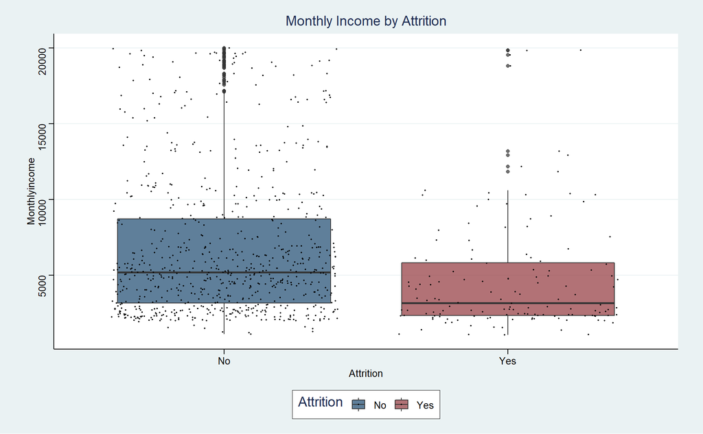

```r
box_plot_check(MonthlyIncome, Attrition, "Monthly Income by Attrition")
```

### Travel

- Fairly unbalanced, most people in “travel rarely” category, but those who travel frequently quit at higher rate - as expected.

```r
hrdf %>% group_by(BusinessTravel) %>% summarize(count = n())
```

```
## # A tibble: 3 x 2
##   BusinessTravel    count
##   <fct>             <int>
## 1 Non-Travel           94
## 2 Travel_Frequently   158
## 3 Travel_Rarely       618
```

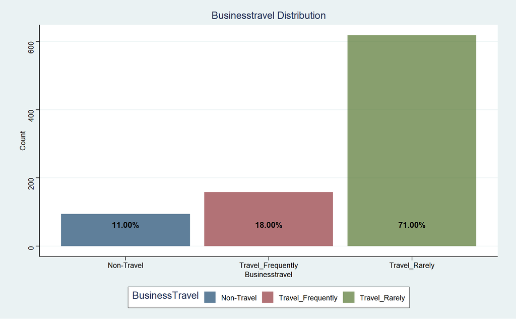

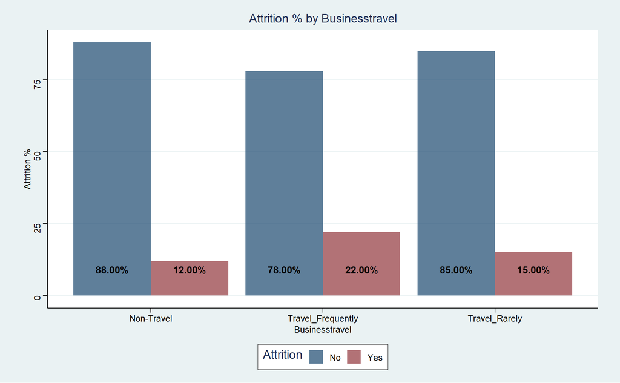

```r
bar_plot_check(BusinessTravel, Attrition)
```

### Distance from home

- Higher distance appears related to more attrition, but no visual evidence of strong relationship, more variance with attrition.

```r
hrdf %>% select(Attrition, DistanceFromHome) %>% group_by(Attrition) %>% skim()
```

Data summary

| Name | Piped data |
| --- | --- |
| Number of rows | 870 |
| Number of columns | 2 |
| _______________________ |  |
| Column type frequency: |  |
| numeric | 1 |
| ________________________ |  |
| Group variables | Attrition |

**Variable type: numeric**

| skim_variable | Attrition | n_missing | complete_rate | mean | sd | p0 | p25 | p50 | p75 | p100 | hist |
| --- | --- | --- | --- | --- | --- | --- | --- | --- | --- | --- | --- |
| DistanceFromHome | No | 0 | 1 | 9.03 | 7.98 | 1 | 2 | 7 | 13 | 29 | ▇▅▁▂▂ |
| DistanceFromHome | Yes | 0 | 1 | 10.96 | 8.75 | 1 | 3 | 9 | 19 | 29 | ▇▅▂▂▃ |

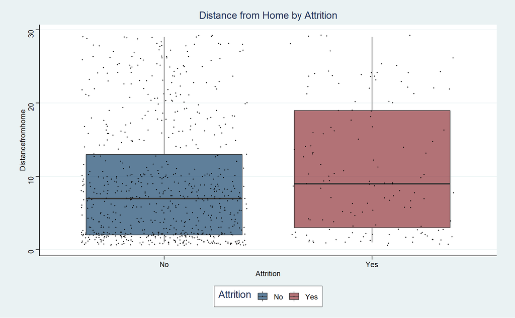

```r
box_plot_check(DistanceFromHome, Attrition, "Distance from Home by Attrition")
```

### Education

- Low # of level five education, that does not appear to be much different attrition than level 4, so grouping together for a potential increase in degrees of freedom.
- Higher education has less attrition, probably correlated with income, etc.
- Education field has unbalanced distributions, so while HR field has the highest attrition rate, with a count of 15, it is probably not a very accurate measure to use.

```r
hrdf %>% group_by(Education) %>% summarize(count = n())
```

```
## # A tibble: 5 x 2
##   Education count
##   <fct>     <int>
## 1 1            98
## 2 2           182
## 3 3           324
## 4 4           240
## 5 5            26
```

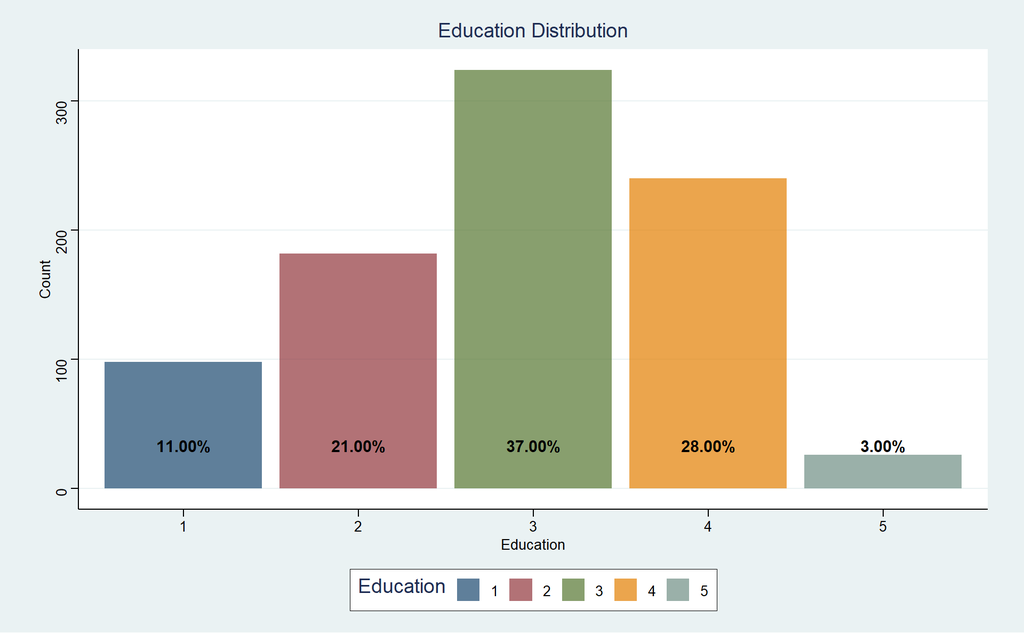

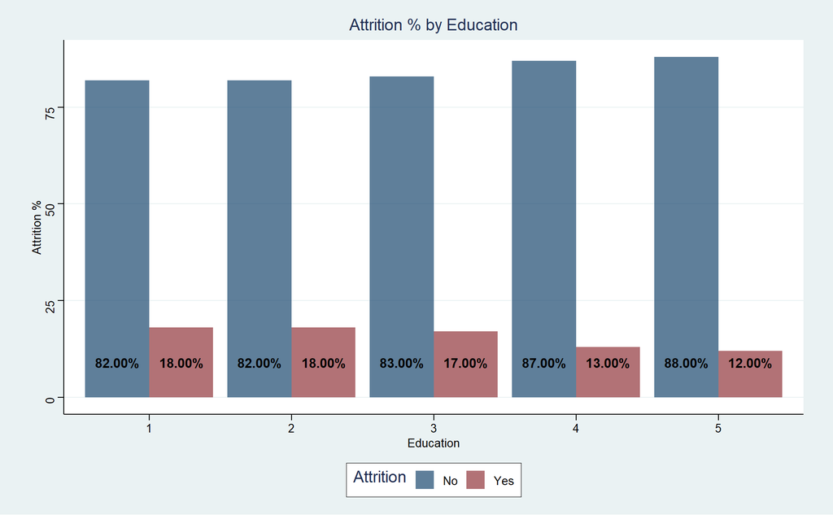

```r
bar_plot_check(Education, Attrition)
```

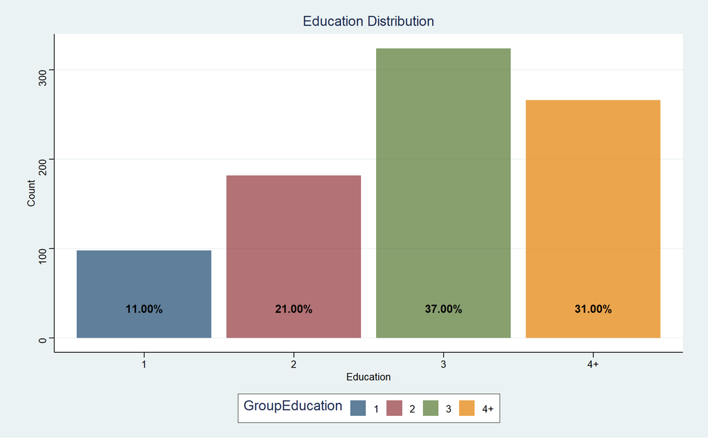

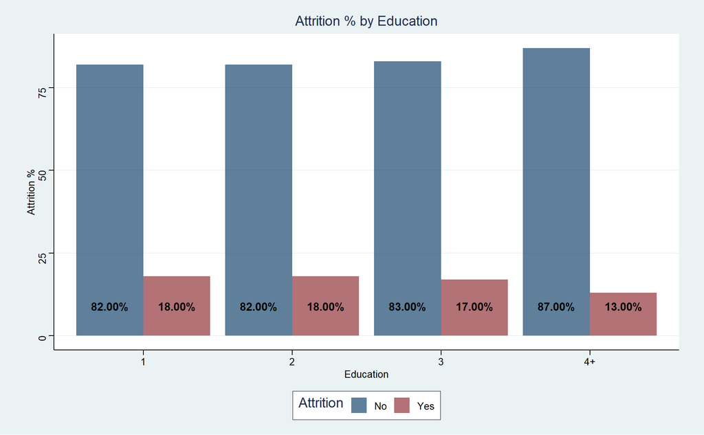

```r
#grouping 4 and 5 together
hrdf$GroupEducation <- ifelse(hrdf$Education %in% c(4,5), "4+",
                              hrdf$Education)

bar_plot_check(GroupEducation, Attrition)
```

```r
hrdf %>% group_by(EducationField) %>% summarize(count = n())
```

```
## # A tibble: 6 x 2
##   EducationField   count
##   <fct>            <int>
## 1 Human Resources     15
## 2 Life Sciences      358
## 3 Marketing          100
## 4 Medical            270
## 5 Other               52
## 6 Technical Degree    75
```

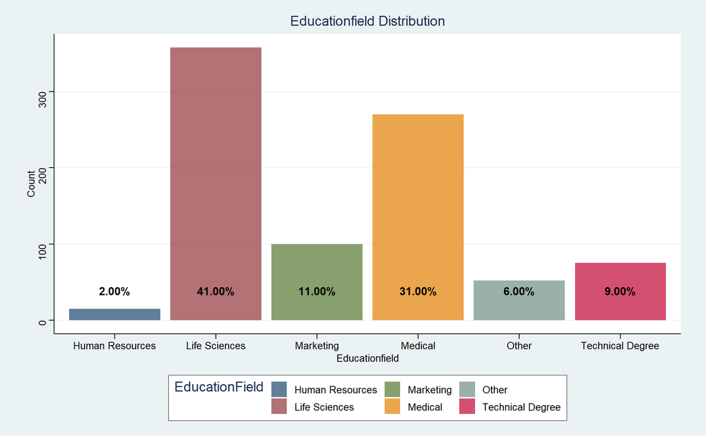

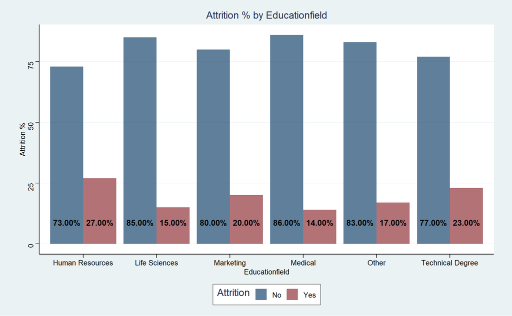

```r
bar_plot_check(EducationField, Attrition)
```

### Age

- Grouping into factor, taking into account distribution but also intuition about ages of “early career”. Attrition seems to decrease as age increases, with the 25 and under bracket leaving at significantly higher rates than others. Age also correlated with income.

```r
summary(hrdf$Age)
```

```
##    Min. 1st Qu.  Median    Mean 3rd Qu.    Max.
##   18.00   30.00   35.00   36.83   43.00   60.00
```

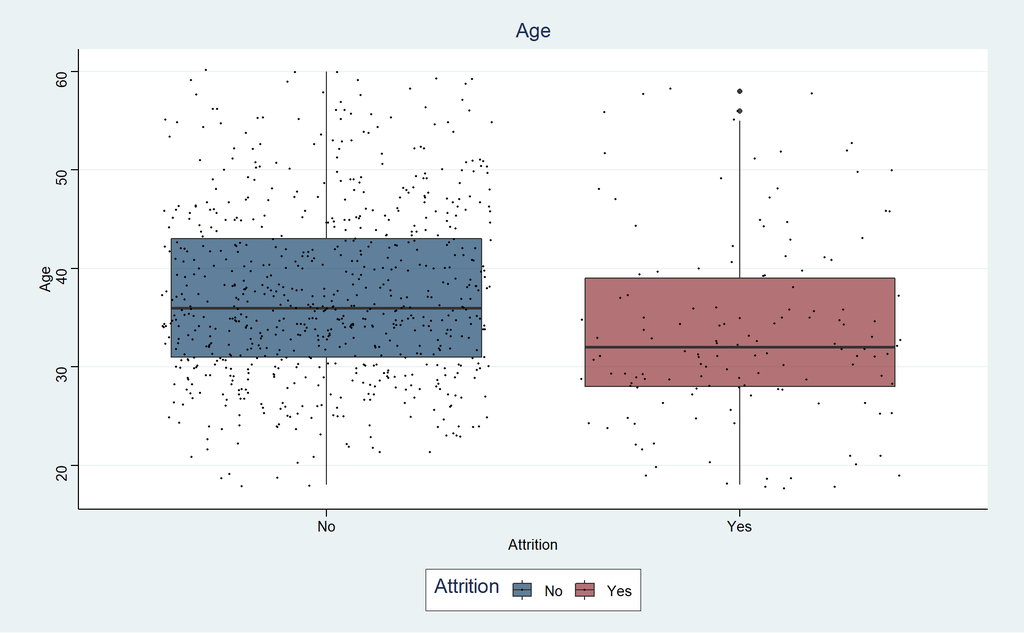

```r
box_plot_check(Age, Attrition, "Age")
```

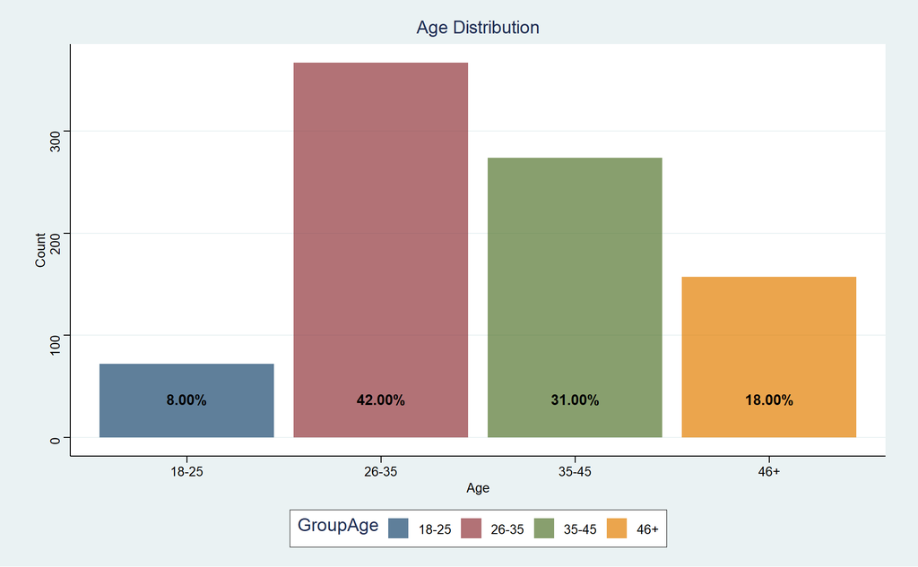

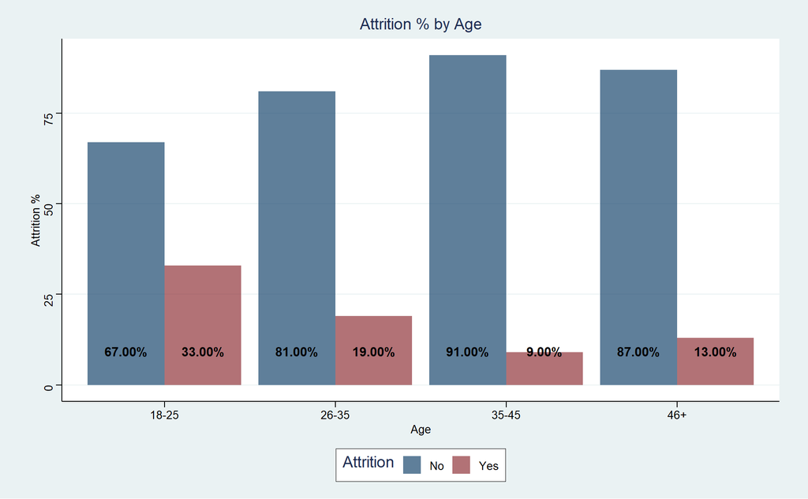

```r
hrdf$GroupAge = cut(hrdf$Age, breaks = c(-1, 25.1, 35.1, 45.1, 100), labels = c("18-25","26-35","35-45","46+"))

bar_plot_check(GroupAge, Attrition)
```

### Department + Job Role Trends

```r
hrdf %>% group_by(Department) %>% summarize(count = n())
```

```
## # A tibble: 3 x 2
##   Department             count
##   <fct>                  <int>
## 1 Human Resources           35
## 2 Research & Development   562
## 3 Sales                    273
```

```r
hrdf %>% group_by(JobRole) %>% summarize(count = n())
```

```
## # A tibble: 9 x 2
##   JobRole                   count
##   <fct>                     <int>
## 1 Healthcare Representative    76
## 2 Human Resources              27
## 3 Laboratory Technician       153
## 4 Manager                      51
## 5 Manufacturing Director       87
## 6 Research Director            51
## 7 Research Scientist          172
## 8 Sales Executive             200
## 9 Sales Representative         53
```

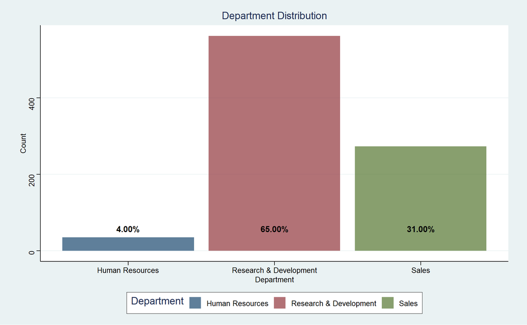

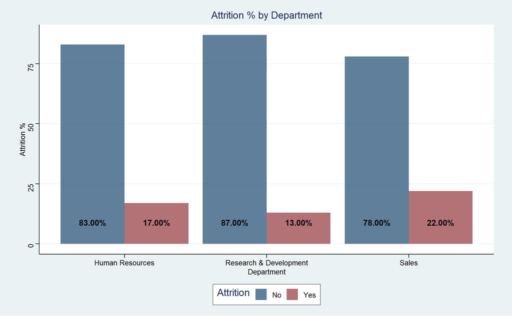

```r
bar_plot_check(Department, Attrition)
```

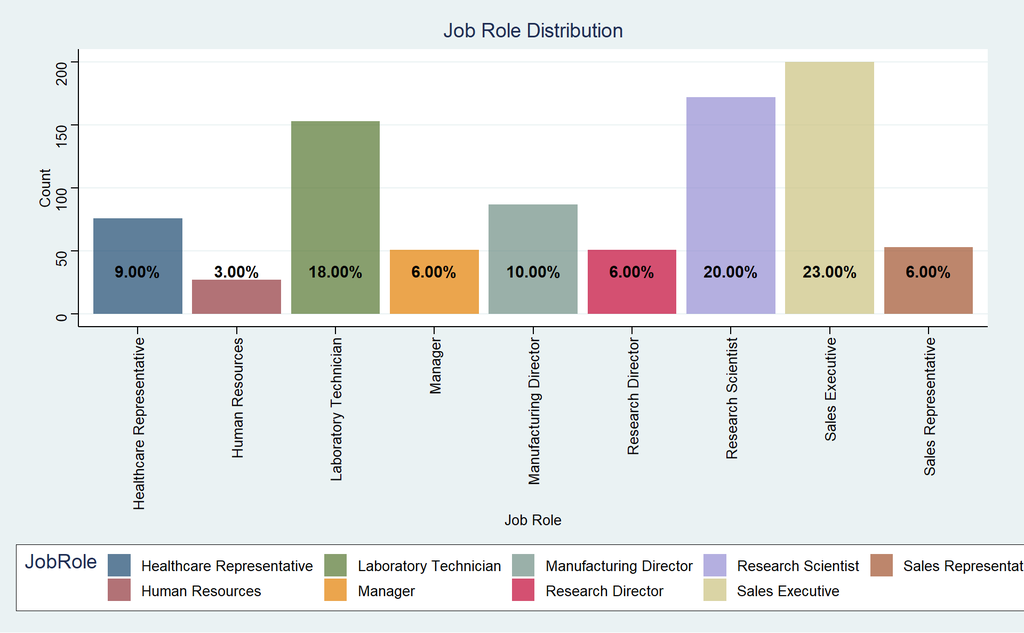

```r
  hrdf %>% group_by(JobRole) %>% summarize(count = n()) %>% mutate(pct=round(prop.table(count),2) * 100) %>%
    ggplot(aes(x = JobRole, y = count, fill = JobRole)) + geom_bar(stat = 'identity', position = 'dodge', alpha = .7) +
    theme_stata() + ggtitle(glue("Job Role Distribution")) + ylab("Count") +
    geom_text(aes(x = JobRole, y=0.01, label= sprintf("%.2f%%", pct)),
              hjust=0.5, vjust=-3, size=4, position = position_dodge(0.9),
              colour="black", fontface="bold") + labs(x = 'Job Role', y="Count") +
      scale_fill_stata() + theme(axis.text.x = element_text(angle = 90, vjust = 0.5, hjust = 1))
```

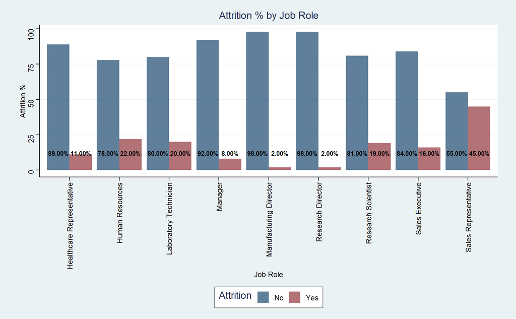

```r
  hrdf %>% group_by(JobRole, Attrition) %>% summarize(count = n()) %>% mutate(pct=round(prop.table(count),2) * 100) %>%
    ggplot(aes(x = JobRole, y = pct, fill = Attrition)) + geom_bar(stat = 'identity', position = 'dodge', alpha = .7) +
    theme_stata() + ggtitle(glue("Attrition % by Job Role")) + ylab("Attrition %") +
    geom_text(aes(x = JobRole, y=0.01, label= sprintf("%.2f%%", pct)),
              hjust=0.5, vjust=-3, size=3, position = position_dodge(0.9),
              colour="black", fontface="bold") + labs(x = 'Job Role', y="Attrition %") +
      scale_fill_stata() + theme(axis.text.x = element_text(angle = 90, vjust = 0.5, hjust = 1))
```

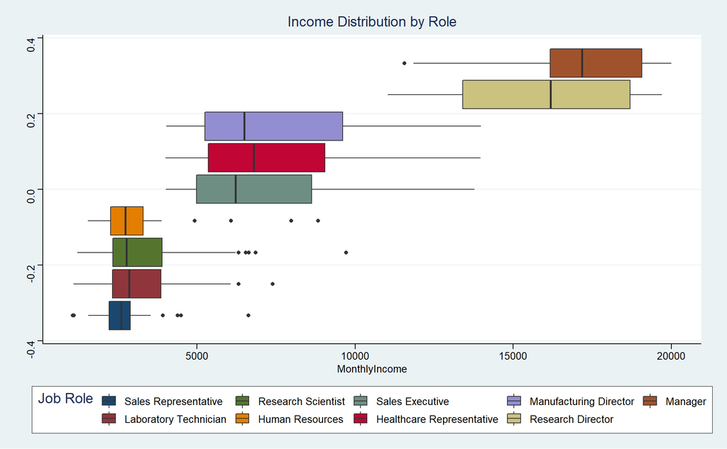

```r
jobdf <- hrdf %>% select(JobRole, JobSatisfaction, WorkLifeBalance, MonthlyIncome, EnvironmentSatisfaction, GroupEducation)

jobdf %>% ggplot(aes(x = MonthlyIncome, fill = reorder(JobRole, MonthlyIncome, mean))) + geom_boxplot() +
  theme_stata() + scale_fill_stata() + ggtitle("Income Distribution by Role") + guides(fill=guide_legend(title="Job Role"))
```

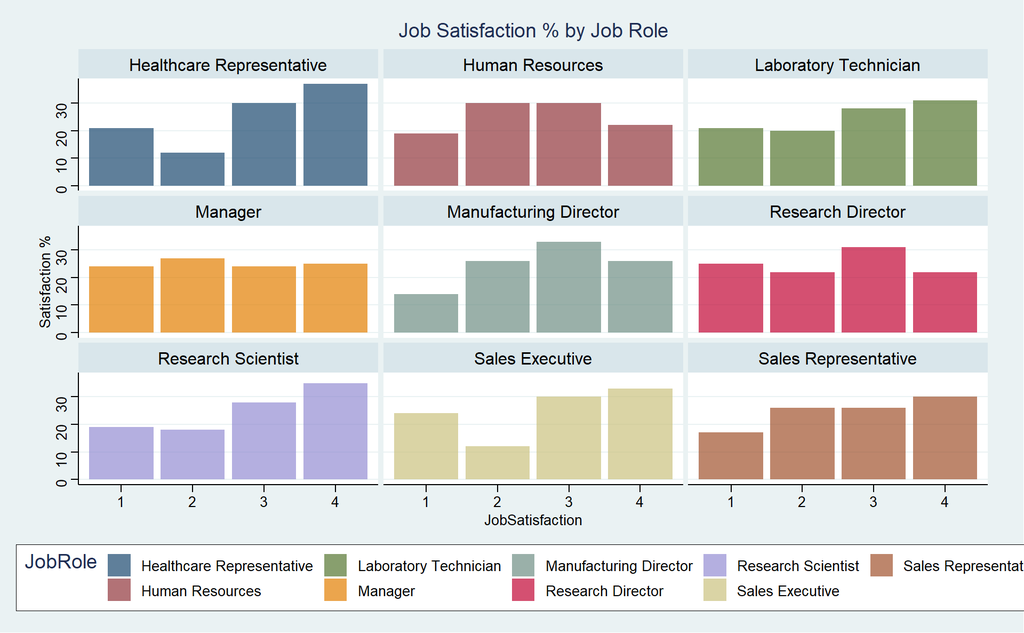

```r
jobdf %>% group_by(JobRole, JobSatisfaction) %>% summarize(count = n()) %>% mutate(pct=round(prop.table(count),2) * 100) %>%
  ggplot(aes(x = JobSatisfaction, y = pct, fill = JobRole)) + geom_bar(stat = 'identity', position = 'dodge', alpha = .7) +
  theme_stata() + ggtitle(glue("Job Satisfaction % by Job Role")) + ylab("Satisfaction %") + facet_wrap(~JobRole) + scale_fill_stata()
```

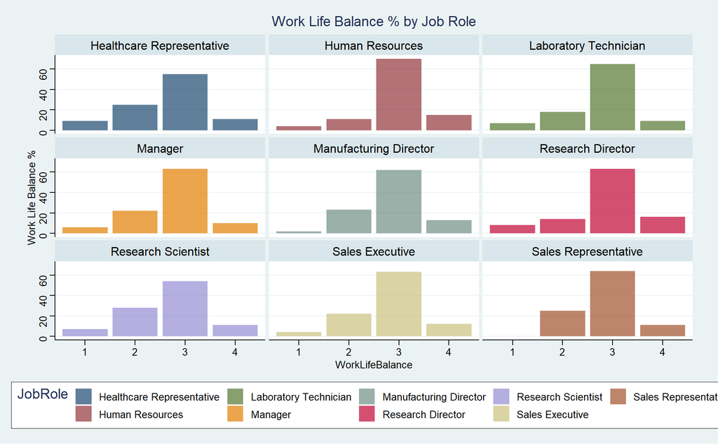

```r
jobdf %>% group_by(JobRole, WorkLifeBalance) %>% summarize(count = n()) %>% mutate(pct=round(prop.table(count),2) * 100) %>%
  ggplot(aes(x = WorkLifeBalance, y = pct, fill = JobRole)) + geom_bar(stat = 'identity', position = 'dodge', alpha = .7) +
  theme_stata() + ggtitle(glue("Work Life Balance % by Job Role")) + ylab("Work Life Balance %") + facet_wrap(~JobRole) + scale_fill_stata()
```

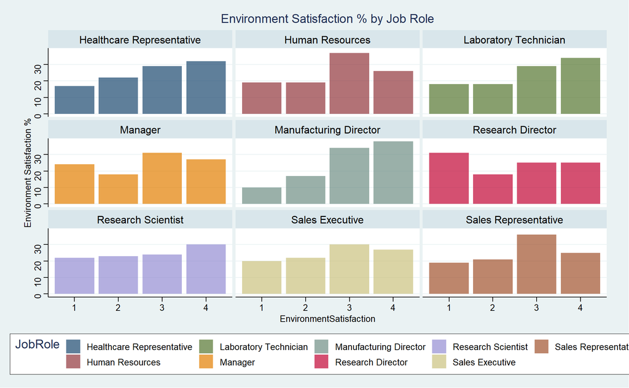

```r
jobdf %>% group_by(JobRole, EnvironmentSatisfaction) %>% summarize(count = n()) %>% mutate(pct=round(prop.table(count),2) * 100) %>%
  ggplot(aes(x =EnvironmentSatisfaction, y = pct, fill = JobRole)) + geom_bar(stat = 'identity', position = 'dodge', alpha = .7) +
  theme_stata() + ggtitle(glue("Environment Satisfaction % by Job Role")) + ylab("Environment Satisfaction %") + facet_wrap(~JobRole) + scale_fill_stata()
```

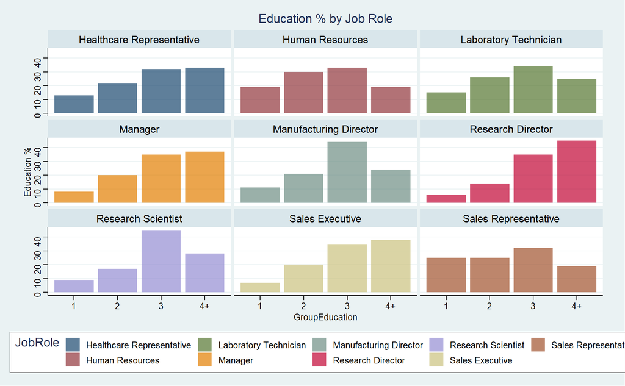

```r
jobdf %>% group_by(JobRole, GroupEducation) %>% summarize(count = n()) %>% mutate(pct=round(prop.table(count),2) * 100) %>%
  ggplot(aes(x = GroupEducation, y = pct, fill = JobRole)) + geom_bar(stat = 'identity', position = 'dodge', alpha = .7) +
  theme_stata() + ggtitle(glue("Education % by Job Role")) + ylab("Education %") + facet_wrap(~JobRole) + scale_fill_stata()
```

### Gender + Marital Status

- Males have a slightly higher turnover rate, however not very significant.
- Marital status on the other hand shows that Single people have a much higher turnover than Married or Divorced people
  - Gender does not make a large difference here either.

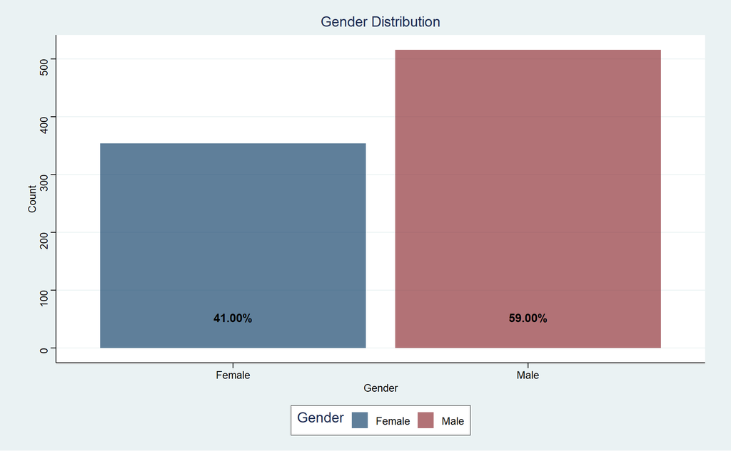

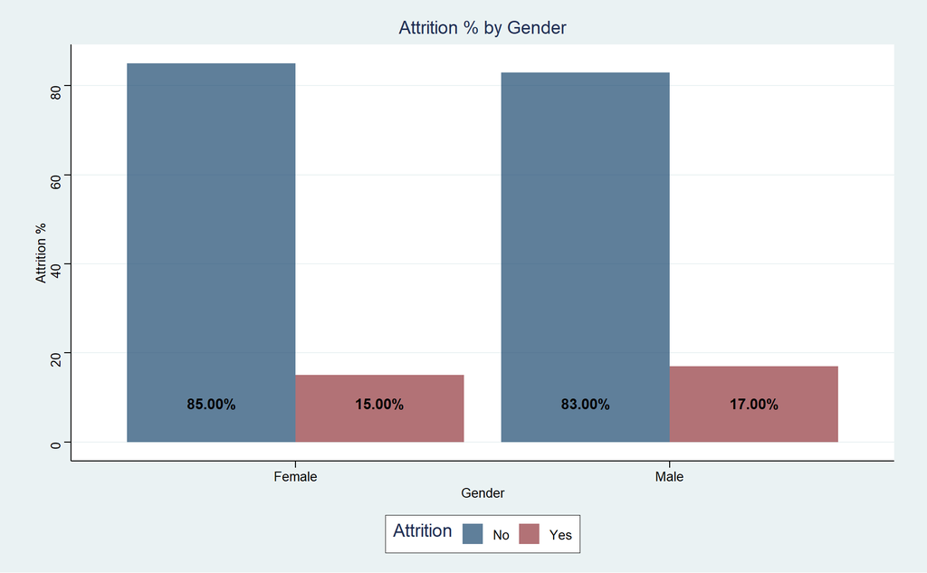

```r
bar_plot_check(Gender, Attrition)
```

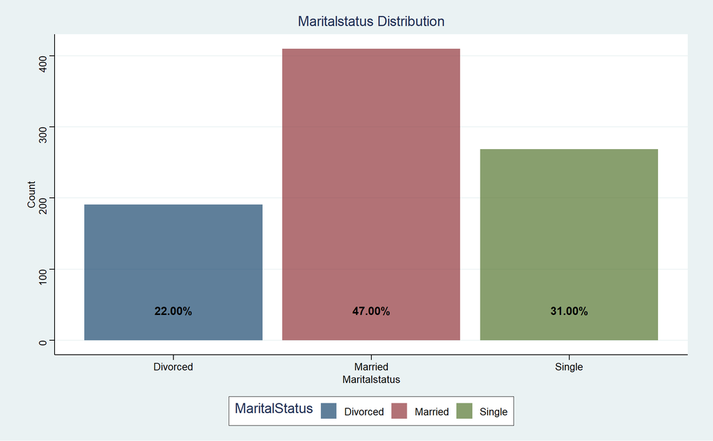

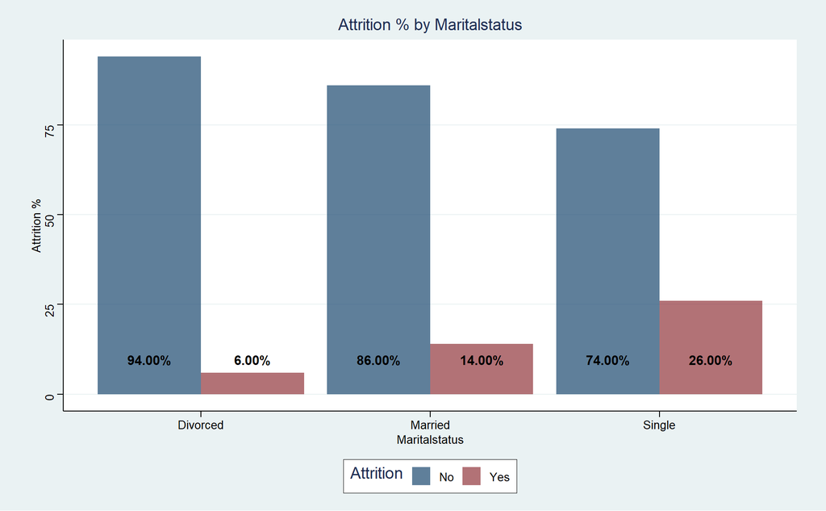

```r
bar_plot_check(MaritalStatus, Attrition)
```

[figure not shown]

```r
  hrdf %>% group_by(Gender, MaritalStatus, Attrition) %>% summarize(count = n()) %>% mutate(pct=round(prop.table(count),2) * 100) %>%
    ggplot(aes(x = Gender, y = pct, fill = Attrition)) + geom_bar(stat = 'identity', position = 'dodge', alpha = .7) +
    theme_stata() + ggtitle(glue("Attrition % by Job Role")) + ylab("Attrition %") +
    geom_text(aes(x = Gender, y=0.01, label= sprintf("%.2f%%", pct)),
              hjust=0.5, vjust=-3, size=3, position = position_dodge(0.9),
              colour="black", fontface="bold") + labs(x = 'Gender', y="Attrition %") +
      scale_fill_stata() + facet_wrap(~MaritalStatus)
```